# project1-YouTube

Long QIN(23829101)

2023-09-03

[YouTube URL:](https://youtu.be/MPLLKMtn9eE) https://youtu.be/MPLLKMtn9eE

# 1 Prepare

## 1.1 Library

```r
library(ggplot2)
library(dplyr)
library(tidyr)
library(gridExtra)
library(stats)
```

## 1.2 Self_defined Function

```r
# get the number of missing data in the column
count_missing <- function(df) {
sapply(df, FUN = function(col) sum(is.na(col)) )
}
#get the number of zero in the column
count_zero_values <- function(df, column) {
  zero_count <- sum(df[[column]] == 0, na.rm = TRUE)
  return(zero_count)
}

# Replace NA values with medians for specific columns
replace_with_median <- function(df, column_names) {
  for (column_name in column_names) {
    median_value <- median(df[[column_name]], na.rm = TRUE)
    df[[column_name]] <- ifelse(is.na(df[[column_name]]), median_value, df[[column_name]])
  }
  return(df)
}

# Replace NA values with "unknown" for specific columns
replace_with_unknown <- function(df, column_names) {
  for (column_name in column_names) {
    df[[column_name]][is.na(df[[column_name]])] <- "unknown"
  }
  return(df)
}

# Function to count zero, negative, and infinite values
count_zero_negative_infinite <- function(column) {
  zero_count <- sum(column == 0)
  negative_count <- sum(column < 0 | is.na(column))
  infinite_count <- sum(is.infinite(column))

  return(c(zero_count, negative_count, infinite_count))
}
```

## 1.3 Load the data

```r
youtube <- read.csv("C:\\Users\\qinlo\\OneDrive\\Desktop\\4009_Computational_Data_Analysis\\week4\\Global YouTube Statistics.csv")

# Replace "nan" and "NaN" with NA in the entire dataframe
youtube <- youtube %>%
  mutate_all(~ ifelse(. %in% c("nan", "NaN"), NA, .))

nrow(youtube)
```

```
## [1] 995
```

```r
count_missing(youtube)
```

```
##                                    rank                                Youtuber
##                                       0                                       0
##                             subscribers                             video.views
##                                       0                                       0
##                                category                                   Title
##                                      46                                       0
##                                 uploads                                 Country
##                                       0                                     122
##                            Abbreviation                            channel_type
##                                     122                                      30
##                        video_views_rank                            country_rank
##                                       1                                     116
##                       channel_type_rank        video_views_for_the_last_30_days
##                                      33                                      56
##                 lowest_monthly_earnings                highest_monthly_earnings
##                                       0                                       0
##                  lowest_yearly_earnings                 highest_yearly_earnings
##                                       0                                       0
##            subscribers_for_last_30_days                            created_year
##                                     337                                       5
##                           created_month                            created_date
##                                       5                                       5
## Gross.tertiary.education.enrollment....                              Population
##                                     123                                     123
##                       Unemployment.rate                        Urban_population
##                                     123                                     123
##                                Latitude                               Longitude
##                                     123                                     123
```

Number of Observations (rows): 995. Number of Variables (columns): 28.

# 2 Data clean

## 2.1 Error data processing

### 2.1.1 Error data in video.views

```r
zero_video.views <- count_zero_values(youtube,"video.views")
cat("Number of Zero in  Video Views:", zero_video.views, "\n")
```

```
## Number of Zero in  Video Views: 8
```

As we can see from the output that There is no invalid values in Subscribers.Among the 995 rows in the dataframe, 8 rows have zero values in the ‘Video Views’ column. Upon closer examination of these eight rows, it’s evident that there are also occurrences of ‘NA’ values scattered throughout these rows, which appear to be random and not systematically related. The occurrence of zero values represents only a small fraction, approximately 0.804% of the entire dataframe.

So I’ll drop these 8 rows, ensuring a more precise analysis of the remaining data.

```r
# Filter rows with zero video views
youtube_v1 <- youtube[youtube$video.views != 0, ]

nrow(youtube_v1)
```

```
## [1] 987
```

995 - 8 == 987 We have successfully removed those 8 rows.

### 2.1.2 Error data increated_year

```r
# Check for values in created_year not within the range 2005 to 2023
out_of_range_years <- youtube_v1$created_year[!(youtube_v1$created_year %in% 2005:2023)]

if (length(out_of_range_years) > 0) {
  cat("Values in created_year not in range 2005 to 2023:", paste(out_of_range_years, collapse = ", "), "\n")
} else {
  cat("All values in created_year are within the range 2005 to 2023.\n")
}
```

```
## Values in created_year not in range 2005 to 2023: 1970, NA, NA, NA, NA, NA
```

So there is only one value that is out of range,and I will drop the rows where the “created_year” is equal to 1970.

```r
youtube_v2 <- youtube_v1[!(youtube_v1$created_year == 1970 & !is.na(youtube_v1$created_year)), ]

nrow(youtube_v2)
```

```
## [1] 986
```

## 2.3 Processing missing value-NAs

```r
# Columns to replace NA values with medians
columns_to_replace <- c(
  "video_views_for_the_last_30_days","subscribers_for_last_30_days","created_year",
  "created_date", "Gross.tertiary.education.enrollment....","Population",
  "Unemployment.rate","Urban_population")

# Call the function to replace NA values with medians for the specified columns
youtube_v2 <- replace_with_median(youtube_v2, columns_to_replace)

# Columns to replace NA values with "unknown"
categorical_columns_to_replace <- c(
  "Country","created_month","Abbreviation","channel_type","category")

# Call the function to replace NA values with "unknown" for the specified columns
youtube_v2 <- replace_with_unknown(youtube_v2, categorical_columns_to_replace)

# drop the columns "Latitude", "Longitude", and "country_rank"
columns_to_drop <- c("Latitude", "Longitude", "country_rank","channel_type_rank","video_views_rank")
youtube_v2 <- youtube_v2[, !(names(youtube_v2) %in% columns_to_drop)]

count_missing(youtube_v2)
```

```
##                                    rank                                Youtuber
##                                       0                                       0
##                             subscribers                             video.views
##                                       0                                       0
##                                category                                   Title
##                                       0                                       0
##                                 uploads                                 Country
##                                       0                                       0
##                            Abbreviation                            channel_type
##                                       0                                       0
##        video_views_for_the_last_30_days                 lowest_monthly_earnings
##                                       0                                       0
##                highest_monthly_earnings                  lowest_yearly_earnings
##                                       0                                       0
##                 highest_yearly_earnings            subscribers_for_last_30_days
##                                       0                                       0
##                            created_year                           created_month
##                                       0                                       0
##                            created_date Gross.tertiary.education.enrollment....
##                                       0                                       0
##                              Population                       Unemployment.rate
##                                       0                                       0
##                        Urban_population
##                                       0
```

# 3 Performance Metrics Comparison

### 3.1 Initial Exploratory

There are elements that could mark the success of the channel,such as subscribers, uploads and income.Now let us see their relations.

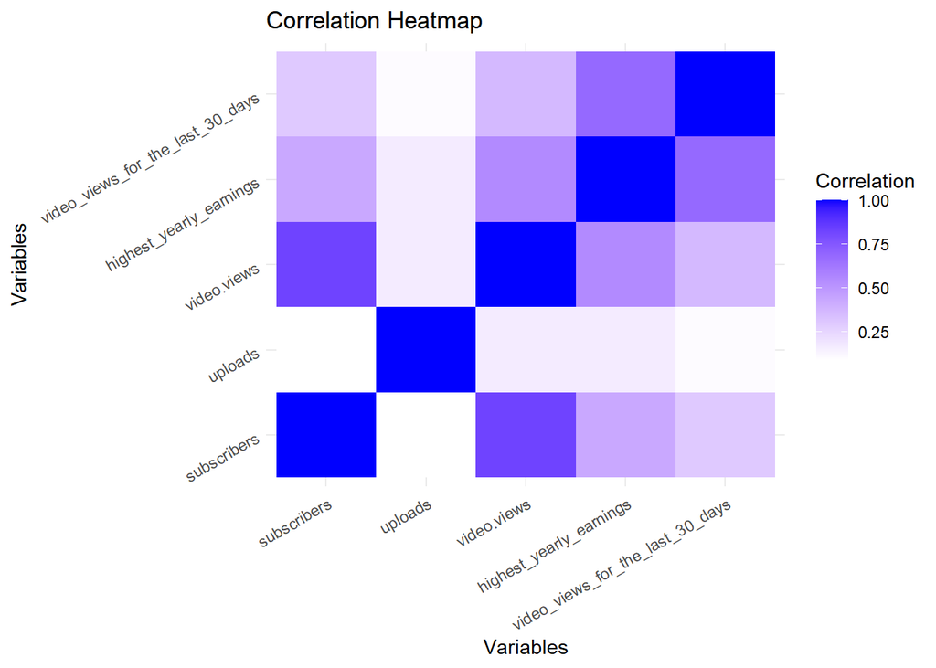

```r
# Calculate the correlation matrix
correlation_matrix <- cor(youtube_v2[c("subscribers", "uploads", "video.views", "highest_yearly_earnings", "video_views_for_the_last_30_days")])

# Convert the correlation matrix to a data frame for plotting
correlation_df <- as.data.frame(as.table(correlation_matrix))
names(correlation_df) <- c("Variable1", "Variable2", "Correlation")

# Create a heatmap plot
ggplot(correlation_df, aes(x = Variable1, y = Variable2, fill = Correlation)) +
  geom_tile() +
  scale_fill_gradient(low = "white", high = "blue") +
  labs(title = "Correlation Heatmap",
       x = "Variables", y = "Variables",
       fill = "Correlation") +
  theme_minimal() +
  theme(axis.text.x = element_text(angle = 30, hjust = 1),
         axis.text.y = element_text(angle = 30, hjust = 1))
```

Weak Correlation between Number of Uploads and other factors: This indicates that the frequency of uploads has a relatively weaker impact on the total views.

Strong Correlation between Number of Subscribers and Views: This suggests that channels with more subscribers tend to have more views.

## 3.2 Subscribers vs. Video Views

Now let us have a closer look at the relation between Subscribers and Video Views

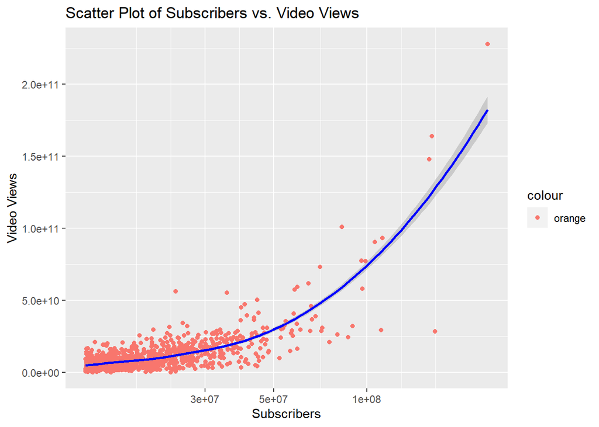

```r
  library(ggplot2)

# Create a scatter plot with green dots and a different color for the smooth line
ggplot(youtube_v2, aes(x = subscribers, y = video.views)) +
  geom_point(aes(color = "orange")) +
  geom_smooth(color = "blue") +
  scale_x_log10() +
  labs(x = "Subscribers", y = "Video Views", title = "Scatter Plot of Subscribers vs. Video Views")
```

As we can see here, Channels with a higher number of subscribers might also have higher video views, but this isn’t always the case.Therefore, it is wise and safe to use Subscribers as the base of the rank of the channel.

## 3.3 Income analysis

Let us further see the several income variables: lowest_monthly_earnings,highest_monthly_earnings,lowest_yearly_earnings,highest_yearly_earnings.

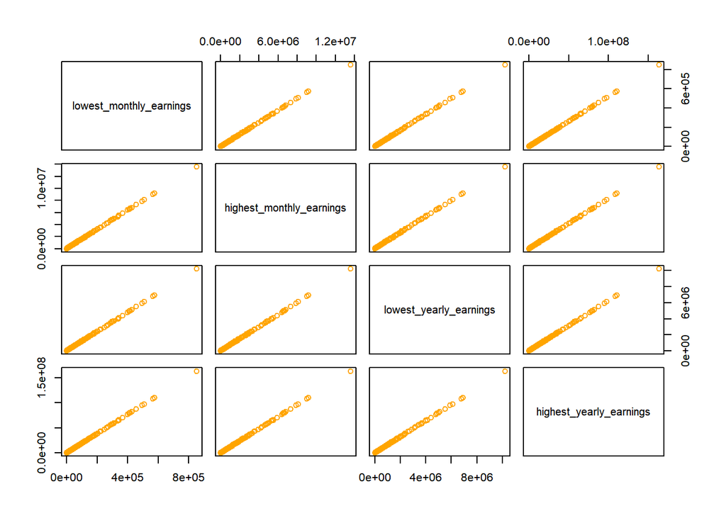

```r
# Select the variables of earning items
variables_of_interest <- youtube_v2[c("lowest_monthly_earnings", "highest_monthly_earnings", "lowest_yearly_earnings", "highest_yearly_earnings")]

# Create a pairwise scatterplot matrix
pairs(variables_of_interest, col = "orange")
```

It’s interesting to note that lowest_monthly_earnings, highest_monthly_earnings, lowest_yearly_earnings, and highest_yearly_earnings are strictly related. as you’ve observed. When these variables are strongly related, it suggests that there is a consistent pattern.Now we can do the following further analysis.

## 3.4 Find the relationship among income items

```r
# lm()for linear regression-library(stats)

# Relationship 1: "highest_monthly_earnings" = A * "lowest_monthly_earnings"
model1 <- lm(highest_monthly_earnings ~ lowest_monthly_earnings, data = youtube_v2)
A1 <- coef(model1)["lowest_monthly_earnings"]

# Relationship 2: "highest_yearly_earnings" = B * "lowest_yearly_earnings"
model2 <- lm(highest_yearly_earnings ~ lowest_yearly_earnings, data = youtube_v2)
A2 <- coef(model2)["lowest_yearly_earnings"]

# Relationship 3: "lowest_yearly_earnings" = C * "lowest_monthly_earnings"
model3 <- lm(lowest_yearly_earnings ~ lowest_monthly_earnings, data = youtube_v2)
B1 <- coef(model3)["lowest_monthly_earnings"]

# Relationship 4: "highest_yearly_earnings" = D * "highest_monthly_earnings"
model4 <- lm(highest_yearly_earnings ~ highest_monthly_earnings, data = youtube_v2)
B2 <- coef(model4)["highest_monthly_earnings"]

# Assuming you have already calculated the coefficients A, B, C, and D

cat("Relationship 1: highest_monthly_earnings = A1 * lowest_monthly_earnings\n")
```

```
## Relationship 1: highest_monthly_earnings = A1 * lowest_monthly_earnings
```

```r
cat("Value of A1:", A1, "\n")
```

```
## Value of A1: 15.98372
```

```r
cat("Relationship 2: highest_yearly_earnings = A2 * lowest_yearly_earnings\n")
```

```
## Relationship 2: highest_yearly_earnings = A2 * lowest_yearly_earnings
```

```r
cat("Value of A2:", A2, "\n")
```

```
## Value of A2: 16.01947
```

```r
cat("Relationship 3: lowest_yearly_earnings = B1 * lowest_monthly_earnings\n")
```

```
## Relationship 3: lowest_yearly_earnings = B1 * lowest_monthly_earnings
```

```r
cat("Value of B1:", B1, "\n")
```

```
## Value of B1: 11.98414
```

```r
cat("Relationship 4: highest_yearly_earnings = B2 * highest_monthly_earnings\n")
```

```
## Relationship 4: highest_yearly_earnings = B2 * highest_monthly_earnings
```

```r
cat("Value of B2:", B2, "\n")
```

```
## Value of B2: 12.01126
```

## 3.5 Income VS video_views_for_the_last_30_days

We previously found that recent video views are strongly associated with the highest yearly earnings. Given the strict linear correlation among the four income-related variables, we will choose only one of earning-related variable for analysis

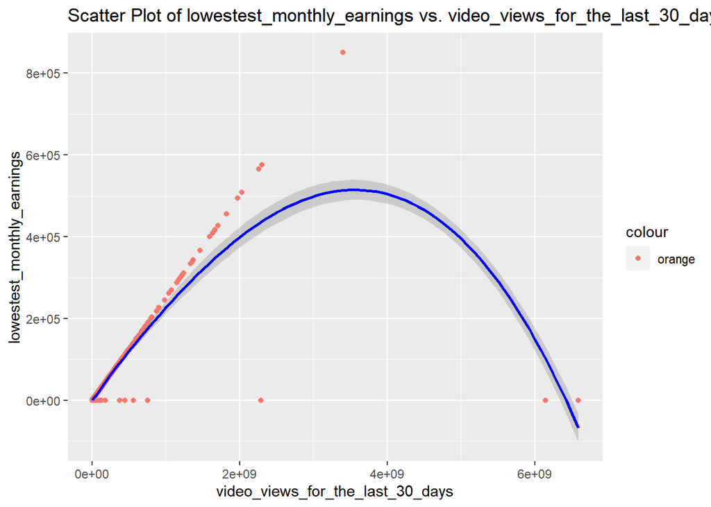

```r
ggplot(youtube_v2, aes(x = video_views_for_the_last_30_days, y = lowest_monthly_earnings)) +
  geom_point(aes(color = "orange")) +
  geom_smooth(color = "blue") +
  labs(x = "video_views_for_the_last_30_days", y="lowestest_monthly_earnings" , title = "Scatter Plot of lowestest_monthly_earnings vs. video_views_for_the_last_30_days")
```

There is a strong linear correlation between “video_views_for_the_last_30_days” and “lowest_monthly_earnings” in your scatter plot. However,there are some instances where “lowest_monthly_earnings” has a value of 0.

## 3.6 Further Data Clean

```r
# Count zero, negative, and infinite values in specified columns
count_zero_negative_infinite(youtube_v2$lowest_monthly_earnings)
```

```
## [1] 110   0   0
```

```r
count_zero_negative_infinite(youtube_v2$highest_monthly_earnings)
```

```
## [1] 83  0  0
```

```r
count_zero_negative_infinite(youtube_v2$lowest_yearly_earnings)
```

```
## [1] 83  0  0
```

```r
count_zero_negative_infinite(youtube_v2$highest_yearly_earnings)
```

```
## [1] 74  0  0
```

```r
## Function to replace 0, negative, and Inf values with calculated values
replace_values <- function(column, model) {
  # Identify rows with 0, negative, or Inf values
  replace_indices <- which(column <= 0 | is.na(column) | is.infinite(column))

  # If there are indices to replace, calculate values using the model
  if (length(replace_indices) > 0) {
    replacement_values <- predict(model, newdata = youtube_v2[replace_indices, ])
    column[replace_indices] <- replacement_values
  }

  return(column)
}

# Replace values in 'lowest_monthly_earnings' with calculated values
youtube_v2$lowest_monthly_earnings <- replace_values(youtube_v2$lowest_monthly_earnings, model3)

# Replace values in 'highest_yearly_earnings' with calculated values
youtube_v2$highest_yearly_earnings <- replace_values(youtube_v2$highest_yearly_earnings, model4)

# Replace values in 'highest_monthly_earnings' with calculated values
youtube_v2$highest_monthly_earnings <- replace_values(youtube_v2$highest_monthly_earnings, model1)

# Replace values in 'lowest_yearly_earnings' with calculated values
youtube_v2$lowest_yearly_earnings <- replace_values(youtube_v2$lowest_yearly_earnings, model2)

# Check the count of zero, negative, and Inf values after replacement
count_zero_values(youtube_v2, "lowest_monthly_earnings")
```

```
## [1] 0
```

```r
count_zero_values(youtube_v2, "highest_monthly_earnings")
```

```
## [1] 0
```

```r
count_zero_values(youtube_v2, "lowest_yearly_earnings")
```

```
## [1] 0
```

```r
count_zero_values(youtube_v2, "highest_yearly_earnings")
```

```
## [1] 0
```

Now the error 0s in these four columns have all been replaced with the predicted data.

# 4 Time Trend

## 4.1 Subscriber and created_year

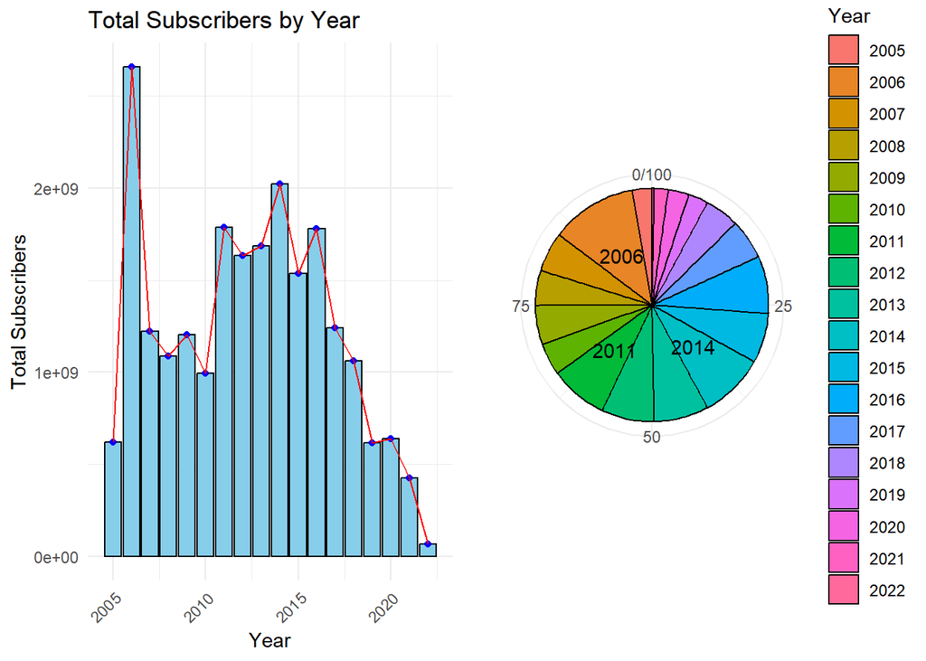

```r
# Calculate total subscribers by year
subscribers_by_year <- youtube_v2 %>%
  group_by(created_year) %>%
  summarise(total_subscribers = sum(subscribers, na.rm = TRUE))


p1 <- ggplot(subscribers_by_year, aes(x = created_year, y = total_subscribers)) +
  geom_bar(stat = "identity", fill = "skyblue", color = "black") +  # Set border color
  ggtitle("Total Subscribers by Year") +
  geom_point(color = "blue") +   # Use geom_point for scatter points
  geom_line(color = "red") +     # Use geom_line for connecting lines
  xlab("Year") +
  ylab("Total Subscribers") +
  theme_minimal() +  # Use minimal theme
  theme(axis.text.x = element_text(angle = 45, hjust = 1))  # Rotate x-axis labels

# Calculate the percentage of total subscribers by year
subscribers_by_year$percentage <- subscribers_by_year$total_subscribers / sum(subscribers_by_year$total_subscribers) * 100

# Sort the data frame by percentage in descending order
subscribers_by_year <- subscribers_by_year[order(subscribers_by_year$percentage, decreasing = TRUE), ]

# Create the circular bar plot with labels for top 3 years
p2 <- ggplot(subscribers_by_year, aes(x = "", y = percentage, fill = factor(created_year))) +
  geom_bar(stat = "identity", width = 1, color = "black") +
  geom_text(aes(label = ifelse(rank(desc(percentage)) <= 3, as.character(created_year), "")), position = position_stack(vjust = 0.5)) +
  ggtitle("") +  # Remove the title
  xlab("") +
  ylab("") +
  theme_minimal() +
  theme(legend.position = "right", legend.box = "horizontal",  # Move legend to the right
        plot.title = element_text(hjust = 0.5, margin = margin(b = -20))) +  # Centered title at the bottom
  coord_polar(theta = "y") +
  scale_fill_discrete(name = "Year")
  #scale_y_continuous(labels = scales::percent_format(scale = 1))

  grid.arrange(p1, p2, ncol = 2)
```

# 5 Geographical Information

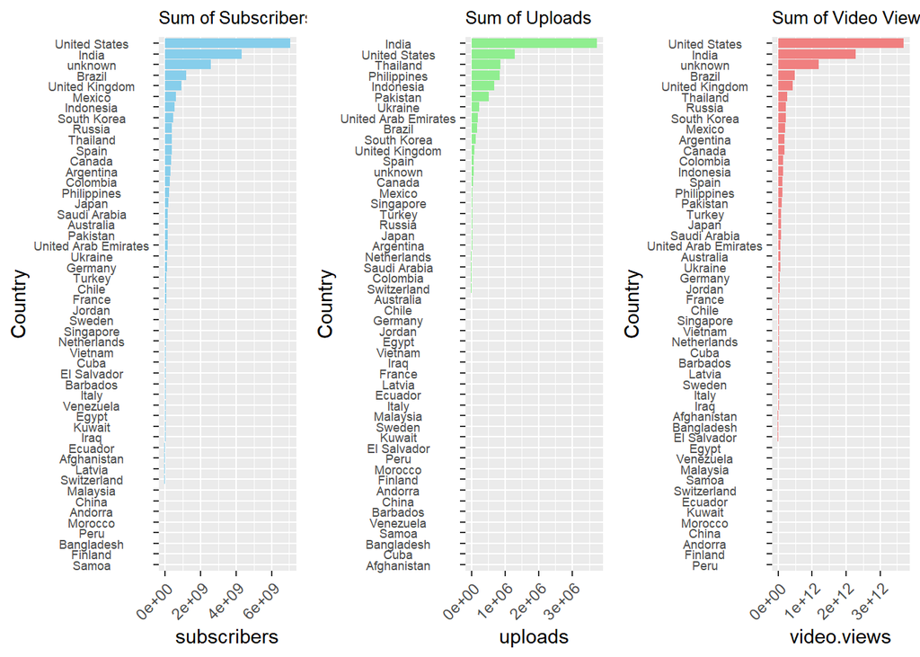

```r
# Assuming you have already aggregated the data for sum of subscribers, uploads, and video views by country
countrysums <- aggregate(subscribers ~ Country, youtube_v2, sum)
countryuploads <- aggregate(uploads ~ Country, youtube_v2, sum)
countryviews <- aggregate(video.views ~ Country, youtube_v2, sum)

# Create the bar plot for subscribers
plot_subscribers <- ggplot(countrysums, aes(x = reorder(Country, subscribers), y = subscribers)) +
  geom_bar(stat = "identity", fill = "skyblue") +
  coord_flip() +
  labs(title = "Sum of Subscribers", x = "Country") +
  theme(
    plot.title = element_text(size = rel(0.9)),
    axis.text.x = element_text(angle = 45, hjust = 1),  # Adjust the x-axis labels
        axis.text.y = element_text(hjust = 0.5, size = rel(0.75)))

# Create the bar plot for uploads
plot_uploads <- ggplot(countryuploads, aes(x = reorder(Country, uploads), y = uploads)) +
  geom_bar(stat = "identity", fill = "lightgreen") +
  coord_flip() +
  labs(title = "Sum of Uploads", x = "Country") +
  theme(axis.text.x = element_text(angle = 45, hjust = 1),
        plot.title = element_text(size = rel(0.9)),
        axis.text.y = element_text(hjust = 0.5, size = rel(0.75)))

# Create the bar plot for video views
plot_views <- ggplot(countryviews, aes(x = reorder(Country, video.views), y = video.views)) +
  geom_bar(stat = "identity", fill = "lightcoral") +
  coord_flip() +
  labs(title = "Sum of Video Views by Country", x = "Country") +
  theme(axis.text.x = element_text(angle = 45, hjust = 1),  # Adjust the x-axis labels
        plot.title = element_text(size = rel(0.9)),
        axis.text.y = element_text(hjust = 0.5, size = rel(0.75)))

# Combine the plots side by side
grid.arrange(plot_subscribers, plot_uploads, plot_views, ncol = 3)
```

Views and Subscribers are more from United States whereas most uploads are from India.

# 6 Category Information

## 6.1 channel_type and country

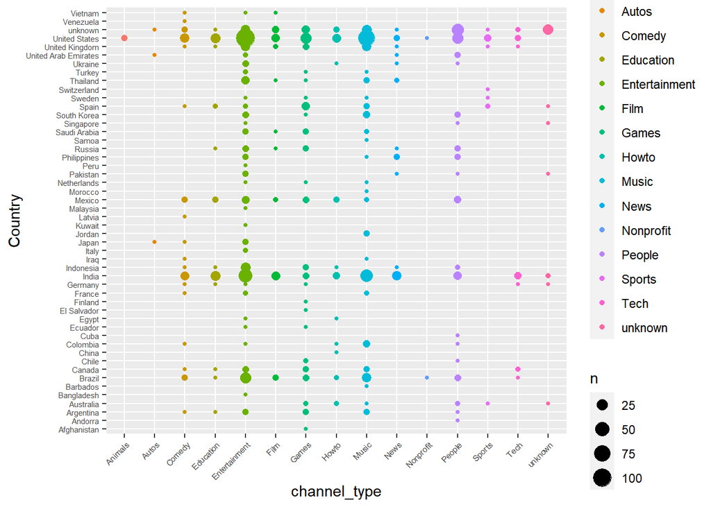

```r
ggplot(data = youtube_v2) +
  geom_count(mapping = aes(x = Country, y = channel_type, color = channel_type)) +
  coord_flip() +
  theme(axis.text.x = element_text(angle = 45, hjust = 1,size = 0.65 * rel(1)),axis.text.y = element_text(size = 0.65 * rel(1)))
```

Entertainment, Music, People, Games,People and Comdey are top 5 YouTube categories.

## 6.2 DATA Transformation - create a new column “TYPE”

As there are so many types in channel_type, and many of them are similar.So I create a new column and we can do the more detailed analysis.

```r
print(unique(youtube_v2$channel_type))
```

```
##  [1] "Music"         "Entertainment" "Education"     "People"
##  [5] "Sports"        "Film"          "News"          "unknown"
##  [9] "Games"         "Comedy"        "Howto"         "Nonprofit"
## [13] "Autos"         "Tech"          "Animals"
```

```r
# Mapping function to group categories
map_category_to_group <- function(category) {
  if (category %in% c("Entertainment", "Games", "Music", "Comedy", "Sports","Film")) {
    return("Entertainment")
  } else if (category %in% c("Education", "Howto", "Tech")) {
    return("Education")
  } else if (category %in% c("News")) {
    return("News")
  } else if (category %in% c("People","Autos","Animals")) {
    return("Life")
  } else {
    return("Other")
  }
}
# Create a new column 'TYPE' based on the mapping function
youtube_v2$TYPE <- sapply(youtube_v2$channel_type, map_category_to_group)

# Print the unique values in the 'TYPE' column
print(unique(youtube_v2$TYPE))
```

```
## [1] "Entertainment" "Education"     "Life"          "News"
## [5] "Other"
```

## 6.3 TYPE and the newest Trend

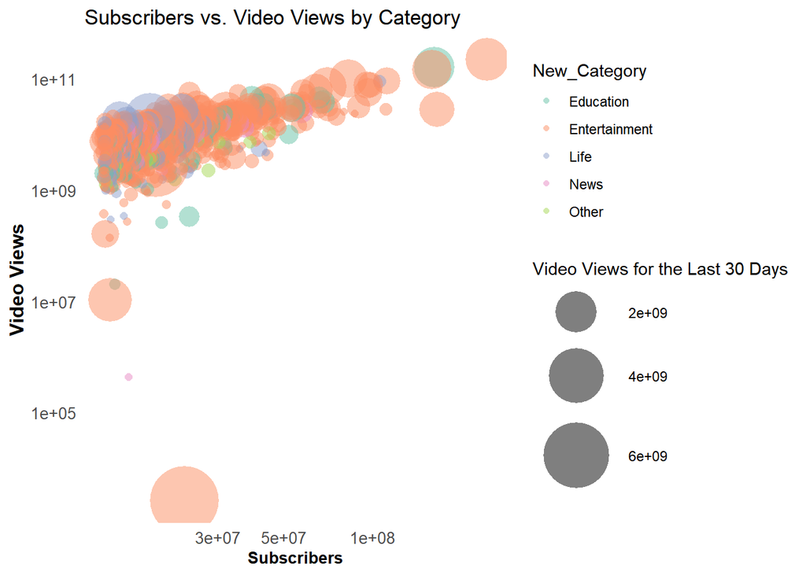

```r
library(RColorBrewer)
# Create the scatter plot with smaller circles
ggplot(youtube_v2, aes(x = subscribers, y = video.views, size = video_views_for_the_last_30_days, color = TYPE)) +
  geom_point(shape = 16, stroke = 0.5, alpha = 0.5) +
  scale_size(range = c(2, 20)) +  # Adjust the size range to smaller values
  labs(title = "Subscribers vs. Video Views by Category",
       x = "Subscribers",  # Updated x-axis label
       y = "Video Views",
       size = "Video Views for the Last 30 Days",
       color = "New_Category") +
  scale_color_brewer(palette = "Set2") +
  theme_minimal() +
  scale_x_log10() +
  scale_y_log10() +
  theme(panel.grid.major = element_blank(),
        panel.grid.minor = element_blank(),
        panel.border = element_blank(),
        axis.text = element_text(size = 10),
        axis.title = element_text(size = 12, face = "bold"),
        axis.title.x = element_text(size = 10))  # Adjust x-axis label font size
```

Entertainment category has most views and subscribers,as well as for the Video Views for the Last 30 Days which is also the newest trend.

# 7 Summary

Performance Metrics: Subscribers often correlate with higher views,and recent views show the strongest correlations with income items.

Geographical Insights: The United States leads in subscribers and views, while India has the highest number of uploads.

Category Analysis: Simplified into five main types, Entertainment channels have the highest engagement and represent the newest trend.

# 8 Shiny

```r
library(shiny)
library(shinydashboard)
```

```r
# Assuming your original data frame is named 'youtube_v2'
youtube_v2 <- youtube_v2[, !(names(youtube_v2) %in% c("rank", "Youtuber", "Title", "Abbreviation"))]

#includes only the columns with numerical data.
numerical_columns <- sapply(youtube_v2, is.numeric)
youtube_numerical <- youtube_v2[, numerical_columns]

#youtube_categorical containing only the categorical columns from the youtube_v2
categorical_columns <- sapply(youtube_v2, is.character) | sapply(youtube_v2, is.factor)
youtube_categorical <- youtube_v2[, categorical_columns, drop = FALSE]

hist_columns <- c(
  "subscribers",
  "video.views",
  "video_views_for_the_last_30_days",
  "subscribers_for_last_30_days"
)
youtube_hist <- youtube_numerical[hist_columns]

ui <- dashboardPage(
  dashboardHeader(title = "Shiny-YouTube"),
  dashboardSidebar(
    sidebarMenu(
      menuItem("Pairwise Plot", tabName = "pairwise", icon = icon("th")),
      menuItem("Scatter Plot", tabName = "scatter", icon = icon("area-chart")),
      menuItem("Histogram Plot", tabName = "histogram", icon = icon("bar-chart")),
      menuItem("Bar Plot", tabName = "barplot", icon = icon("line-chart"))
    )
  ),
  dashboardBody(
    style = "background-color: #E6F5E6; padding-bottom: 0; height: calc(100vh - 80px);",  # Adjusted height to cover the entire remaining space
    tabItems(
      tabItem("pairwise",
              sidebarLayout(
                sidebarPanel(
                  selectizeInput("selected_attributes", "Select attributes:", names(youtube_numerical), multiple = TRUE)
                ),
                mainPanel(
                  plotOutput("pairwise_plot")
                )
              )),
      tabItem("scatter",
              sidebarLayout(
                sidebarPanel(
                  selectInput("x_attr", "Select x-axis attribute:", names(youtube_numerical)),
                  selectInput("y_attr", "Select y-axis attribute:", names(youtube_numerical))
                ),
                mainPanel(
                  plotOutput("scatter_plot")
                )
              )),
      tabItem("histogram",
              sidebarLayout(
                sidebarPanel(
                  selectInput(inputId = "x1", label = "Choose x:", choices = names(youtube_hist)),
                  sliderInput("bins", "Number of bins:", min = 1, max = 100, value = 20)
                ),
                mainPanel(
                  plotOutput("hist_plot")
                )
              )),
      tabItem("barplot",
              sidebarLayout(
                sidebarPanel(
                  selectInput("barplot_var", "Select variable for bar plot:", names(youtube_categorical))
                ),
                mainPanel(
                  plotOutput("barplot_plot")
                )
              )
      )
    )
  )
)

server <- function(input, output) {
  output$pairwise_plot <- renderPlot({
    selected_attrs <- input$selected_attributes
    if (length(selected_attrs) < 2) {
      return(NULL)
    }
    pairs(youtube_numerical[, selected_attrs])
  })

  output$scatter_plot <- renderPlot({
    x_attr <- input$x_attr
    y_attr <- input$y_attr
    ggplot(youtube_numerical, aes_string(x = x_attr, y = y_attr)) +
      geom_point() + geom_smooth()+theme_minimal()

  })

  generate_histogram <- function(data, x_var, title) {
  ggplot(data, aes_string(x = x_var)) +
    scale_x_log10() +
    geom_histogram(bins = 20, color = "white") +
    labs(title = title, x = x_var, y = "Frequency") +  # Set x-axis label to the input variable name
    theme_minimal() +
    theme(axis.text.x = element_text(angle = 45, hjust = 1))# Rotate x-axis labels for  readability
}

output$histogram <- renderPlot({
  generate_histogram(youtube_numerical, input$x1, input$x1)  # Pass input$x1 as the x-axis label
})

output$hist_plot <- renderPlot({
  x <- youtube_hist[, input$x1]
  x <- log10(x + 1e-10)
  bins <- seq(min(x), max(x), length.out = input$bins + 1)
  hist(x, breaks = bins, col = 'darkgray', border = 'white',
       xlab = input$x1,
       main = paste("Histogram of", input$x1),
       xaxt = "n"  # Remove default x-axis labels
  )
  # Customize x-axis labels for the "subscribers" variable  reference ChatGPT
  if (input$x1 == "subscribers") {
    axis(1, at = seq(7, 9, by = 0.1), labels = format(10^seq(7, 9, by = 0.1), scientific = FALSE))
  } else{
    axis(1, at = seq(floor(min(x)), ceiling(max(x)), by = 1), labels = 10^seq(floor(min(x)), ceiling(max(x)), by = 1))
  }
})

  #barplot_plot
  output$barplot_plot <- renderPlot({
  barplot_data <- youtube_categorical %>%
    group_by(.data[[input$barplot_var]]) %>%
    summarise(count = n()) %>%
    arrange(desc(count))  # Arrange by count in descending order

  ggplot(barplot_data, aes(x = reorder(.data[[input$barplot_var]], -count), y = count, fill = .data[[input$barplot_var]])) +
    coord_flip() +
    geom_bar(stat = "identity") +
    labs(
      x = input$barplot_var,
      y = "Count",
      title = paste("Bar Plot of", input$barplot_var)
    ) +
    theme_minimal() +
    theme(axis.text.x = element_text(angle = 45, hjust = 1))
})
}
shinyApp(ui = ui, server = server)
```

Shiny applications not supported in static R Markdown documents